# Working with Text

This blog post will walk you through how I was able to take a pdf version of Harry Potter and the Sorcerers Stone and plot the top five words per chapter and perform a sentiment analysis.

Annika Leiby true  
03-10-2021

```r
# Attach Packages

library(tidyverse)
library(tidytext)
library(textdata)
library(pdftools)
library(ggwordcloud)
```

### Data Source:

The analysis for this task comes from a pdf version of the first book in the Harry Potter series titled Harry Potter and the Sorcerers Stone. The pdf comes from getfreestories.weebly.com. and can be accessed at http://www.getfreestories.weebly.com/uploads/7/9/0/2/79020522/harry_potter_and_the_sorcerers_-_j.k._rowling.pdf.

### Part 1: Import text of your choosing

I imported a pdf version of Harry Potter and the Sorcerers Stone, the first book in J.K. Rowlings series Harry Potter.

```r
# Read in the Harry Potter pdf using the function pdf_text()

harry_potter_text <- pdf_text("hp_sorcerers_stone.pdf")

# Look at it run View(harry_potter_text) in console
# Look at a random page to see what symbol is breaking up the lines
# Can see that it is "\n"

# hp_text_p39 <- harry_potter_text[39]

# hp_text_p39
```

### Part 2: Wrangle the data to get tokens into tidy format and remove stop words.

```r
# Need to get it into tidy format
# First convert to a data frame.
# Then mutate a new column called text_full where you use the str_split function on column harry_potter_text to split at the pattern "\n" have to put an extra "\" in front
# Use the un nest function on the text_full column to make each line have its own row
# Remove excess white space with str_trim function

harry_potter_tidy <- data.frame(harry_potter_text) %>%
  mutate(text_full = str_split(harry_potter_text, pattern = "\\n")) %>%
  unnest(text_full) %>%
  mutate(text_full = str_trim(text_full))
```

```r
# Close, but for true tidy format we want each row to have its own word
# Notice there are 44 rows until you get to "Chapter 1"
# Use slice(-(1:44)) to remove rows 1-44

# Want to group by chapter so that can do analysis by chapter
# Use string detect to detect the chapter number in the column text_full
# If chapter does appear then repeat it but if it does not than make it an n/a
# Have to give the NA a behind the scenes class of character
# Then use fill() to fill all na until it gets to the next non na value

harry_potter_df <- harry_potter_tidy %>%
  slice(-(1:44)) %>%
  mutate(chapter = case_when(
    str_detect(text_full, pattern = "CHAPTER") ~ text_full, TRUE ~ NA_character_)) %>%
  fill(chapter) %>%
  separate(col = chapter, into = c("ch", "no"), sep = " ")
```

```r
# Now to get it in tokenized text format with each token as a single word
# Use unnest_tokens() function to split an existing column into tokens
# With the new column called word and coming from text_full
# To get rid of the original harry_potter_text column use select(- harry_potter_text)

harry_potter_tokens <- harry_potter_df %>%
  unnest_tokens (word, text_full) %>%
  dplyr::select(-harry_potter_text)
```

### Part 3: Find counts and make a column graph visualization of counts for most frequently used words in text by chapter.

```r
# Now to get word counts by chapter

harry_potter_wordcount <- harry_potter_tokens %>%
  count(no, word)

# harry_potter_wordcount

# Remove the stop words like "a" "the"
# use the function anti_join() to do this

harry_potter_nonstop_words <- harry_potter_tokens %>%
  anti_join(stop_words)

nonstop_counts <- harry_potter_nonstop_words %>%
  count(no, word)

# nonstop_counts
```

[figure not shown]

```r
# Find top 5 words by chapter
# Group by chapter number "no" and arrange from highest count words to lowest count words using arrange() function
# Use the slice() function to only get the top 5 words for each chapter
# Filter our main character names and filler words

top_5_words <- nonstop_counts %>%
  filter(!word %in% c("ron","harry", "hermione", "potter", "hagrid", "didn’t", "ver", "veh", "ter", "it’s", "he’s", "professor", "he’d", "vernon", "petunia", "couldn’t", "i’ve", "don’t", "i’m", "yer", "yeh", "snape", "ronan", "don", "boy", "dumbledore", "dudley", "mcgonagall", "looked", "harry’s", "dursleys", "people", "can’t", "told")) %>%
  group_by(no) %>%
  arrange(-n) %>%
  slice(1:5)

#Note, the "'" did not work at first since it is the more curly version one in the text so I copied and pasted the "’" from the data frame itself.

# Make a column graph of the word counts facet wrapping by chapter
ggplot(data = top_5_words, aes(x = word, y = n)) +
  geom_col(aes(fill = no), show.legend = FALSE) +
  facet_wrap(~no, scales = "free") +
  coord_flip() +
  labs(x = "Word", y = "Count")
```

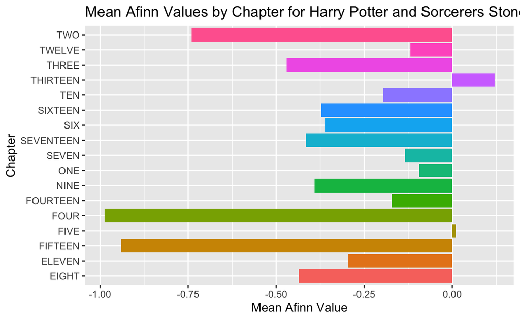

```r
# Now for sentiment analysis
# What sentiments seem to be most prevalent in each of these chapters?
# Using the NRC lexicon

harry_potter_nrc <- harry_potter_nonstop_words %>%
  inner_join(get_sentiments("nrc"))

harry_potter_nrc_counts <- harry_potter_nrc %>%
  count(no, sentiment)

#ggplot(data = harry_potter_nrc_counts, aes(x #= sentiment, y = n)) +
#  geom_col() +
#  facet_wrap(~no) +
#  coord_flip()


# Using afinn


harry_potter_afinn <- harry_potter_nonstop_words %>%
  inner_join(get_sentiments("afinn"))

# Get counts for each score for every chapter

afinn_counts <- harry_potter_afinn %>%
  count(no, value)

# Getting a mean value for sentiment can be useful

afinn_means <- harry_potter_afinn %>%
  group_by(no) %>%
  summarize(mean_afinn = mean(value))

ggplot(data = afinn_means, aes(x = no, y = mean_afinn)) +
  geom_col(aes(fill = no), show.legend = FALSE) +
  coord_flip() +
  labs(x = "Chapter", y = "Mean Afinn Value", title = "Mean Afinn Values by Chapter for Harry Potter and Sorcerers Stone")
```